# Stochastic Generation of Daily Precipitation Time Series

Emanuele Cordano

2022-01-18

## Overview

Stochastic generators of weather variables, called “Weather Generators” (WGs) have been widely developed in the recent decades for hydrological and agricultural applications (e.g. Richardson (1981) Racsko, Szeidl, and Semenov (1991), Mikhail A. Semenov and Barrow (1997), Parlange and Katz (01 May. 2000),Liu et al. (2009),J. Chen, Brissette, and Leconte (2012),Jie Chen and Brissette (2014),Cordano and Eccel (2016), Verdin et al. (2018) ). These instruments have been used in several applications related to plant phenology and agriculture (e.g. Delerce et al. (2016), Benmoussa et al. (2018), Alikadic et al. (2019)) and hydroclimatic case studies (e.g. Fu, Chiew, and Shi (2018), Ahn and Steinschneider (2018)). Former applications of WGs are the reproductions of daily weather time series from downscaled monthly climate predictions (Mearns et al. (2001),Wilks and Wilby (1999),Qian, Corte-Real, and Xu (2002),M. A. Semenov and Stratonovitch (2010)). If high-resolution application models are to be used with downscaled series, a meteorological consistence of generated series is required, suggesting the use of a multi-site weather generator. Algorithms to represent historical spatial dependences of weather variables have been developed by Wilks (1998),Khalili, Brissette, and Leconte (2009),Serinaldi (2009) and Bárdossy and Pegram (2009). Wilks (1998) simulated rainfall occurrences through a generation of combinations of Gaussian random variables and established a relationship for each pair of rain gauges between Gaussian variables correlation and binary precipitation occurrence values. In this way, weather generators can reproduce at least partially spatial correlations. This approach is widely cited in literature (e.g. Mehrotra, Srikanthan, and Sharma (2006),Brissette, Khalili, and Leconte (2007),Serinaldi (2009),Thompson, Thomson, and Zheng (2007),Mhanna and Bauwens (2011)).  
In principle, **RMAWGEN** (RMultisite Auto-regressive Weather Generator) was developed to cope with the demand for high-resolution climatic scenarios but also to create a flexible tool for engineers, climatologists, and environmental sciences modellers. Recently, statistical methods useful for weather generation, originally developed in environmetrics and econometrics, were made available in the R platform. **RMAWGEN** uses R’s existing tools for vector auto-regressive models (Pfaff (2008)), employed for generation of weather variables (Adenomon and Oyejola (2013),Luguterah, Nasiru, and Anzagra (2013),Shahin, Ali, and Ali (2014)), and to let the end users work with other R spatio-temporal tools for data analysis and visualization (Bivand, Pebesma, and Gomez-Rubio (2008),Loecher and Berlin School of Economics and Law (2012),Kahle and Wickham (2013),Cheng, Karambelkar, and Xie (2018)). **RMAWGEN** (Cordano and Eccel (2019)) carries out generations of weather series through Vector Auto-regressive Models; the latter work generally well for time-continuous variables, but present some critical issues for intermittent weather variables like precipitation. Meanwhile, **RGENERATE** (Cordano (2015)) has been created to create several the stochasic generation algorithms by using a unique S3/S4 method called starting from the ones in **RMAWGEN** to other models, where stochastic weather generations follow different algorithms. **RGENERATEPREC** contains an extension the *generate* methods in order to make a stochstic generation of precipitations, using logistic regression instead of linear regression used for the Gaussianized variables in **RMAWGEN**.

## Introduction

The scope of this vignette is a generation of stochastic times series of daily precipitatoion with the same stastistical properties (e.g. probability distrubtions of precipitation occurrence, precipitation account, dry spell, wet spell per each month of the year) of the observed one(s). The weather generator can work with one or more time series generating scenarios for several sites and mantainig their spatial cross-correlation. This vignette shows an example of a stochastic generation based on a single observed time series in a rainfall gauging station and a generation of several time series based on a network of rainfall gauging stations. Therefore, an examples of stochastic generator of daily time series based on climate possible projections when precipitation amount probability distribution is assigned. The examples make used of the example dataset already presented in **RMAWGEN** package, dataset already imported by **RGENERATEPREC**. Therefore, package *RGENARATEPREC* and other necessary packages are loaded as follows:

```r
library(RGENERATEPREC)
library(lubridate)
```

## Trentino Example Dataset

The *trentino* dataset, provided by **RMAWGEN** package, is a collection of daily values of precipitation, minimum temperature, maximum temperature in a 50-year long temporal window from 1958-01-01 to 2007-12-31 .

```r
data(trentino)
```

The stations are spread in a territory covering Trentino and its neighbourhood (Cheng, Karambelkar, and Xie (2018)).

```r
library(sf)
library(mapview)

trentino_stations <- data.frame(x=STATION_LATLON[,1],y=STATION_LATLON[,2],name=STATION_NAMES)
######
trentino_stations$geometry <- trentino_stations[,c("x","y")] %>% t() %>% as.data.frame() %>% as.list() %>% lapply(st_point) %>% st_sfc()
trentino_stations <- st_sf(trentino_stations,geometry=trentino_stations$geometry,crs=4326)
mapview(trentino_stations,col.regions="blue")
```

[interactive chart not shown]

Weather data are contained in three data frames (one for each variable) where the first 3 columns refer to year, month and day whereas the other columns refer to each gauging station.

```r
str(TEMPERATURE_MAX)
str(TEMPERATURE_MIN)
str(PRECIPITATION)
```

A reference period between 1961 and 1990 is taken:

```r
year_min <- 1961
year_max <- 1990

origin <- paste(year_min,1,1,sep="-")
period <- PRECIPITATION$year>=year_min & PRECIPITATION$year<=year_max
period_temp <- TEMPERATURE_MAX$year>=year_min & TEMPERATURE_MAX$year<=year_max
```

The time series in the reference period are saved as new variables: *prec_mes*,*Tx_mes* and *Tn_mes*:

```r
prec_mes <- PRECIPITATION[period,]
Tx_mes <- TEMPERATURE_MAX[period_temp,]
Tn_mes <- TEMPERATURE_MIN[period_temp,]
```

The analysis has been focused only on the stations whose time series is completed within the reference period.

```r
accepted <- array(TRUE,length(names(prec_mes)))
names(accepted) <- names(prec_mes)
for (it in names(prec_mes)) {
    acc <- TRUE
    acc <- (length(which(!is.na(Tx_mes[,it])))==length(Tx_mes[,it]))
    acc <- (length(which(!is.na(Tn_mes[,it])))==length(Tn_mes[,it])) & acc
    accepted[it]  <- (length(which(!is.na(prec_mes[,it])))==length(prec_mes[,it])) & acc

}
```

The station involved in the computation are then the following:

```r
names(accepted)
```

```
#>  [1] "month" "day"   "year"  "T0001" "T0010" "T0014" "T0018" "T0021" "T0024"
#> [10] "T0032" "T0064" "T0074" "T0082" "T0083" "T0090" "T0092" "T0094" "T0099"
#> [19] "T0102" "T0103" "T0110" "T0129" "T0139" "T0147" "T0149" "T0150" "T0152"
#> [28] "T0154" "T0157" "T0160" "T0163" "T0166" "T0168" "T0169" "T0172" "T0175"
#> [37] "T0179" "T0189" "T0193" "T0204" "T0210" "T0211" "T0236" "T0327" "T0355"
#> [46] "T0360" "T0367" "T0370" "T0373" "B2440" "B6130" "B7810" "B8570" "B9100"
#> [55] "LFORN" "LAVIO" "LVACC" "VBARD" "VCAST" "VDOLC" "SMICH" "POLSA"
```

Three data frames for observed values of daily precipitation:

```r
prec_mes <- prec_mes[,accepted]
head(prec_mes)
```

```
#>      month day year T0001 T0014 T0064  T0083 T0090  T0129 T0139 T0211 T0367
#> 1097     1   1 1961   0.0  0.00   0.0  0.000  0.00  0.000  0.00   1.3   0.0
#> 1098     1   2 1961  10.8  7.38  14.0  6.765  0.00 12.900  9.43  15.5  10.4
#> 1099     1   3 1961   0.0  0.00   0.0  0.000  0.00  0.172  0.00   0.0   0.0
#> 1100     1   4 1961  22.2 25.56  32.5 61.500 12.96 33.368 17.25  38.3   8.0
#> 1101     1   5 1961   0.0  0.00   0.0  0.000  0.00  0.000  0.00   0.0   0.0
#> 1102     1   6 1961   0.0  0.00   0.0  0.000  0.00  0.000  0.00   0.0   1.0
```

;maximum temparature:

```r
Tx_mes <- Tx_mes[,accepted]
head(Tx_mes)
```

```
#>      month day year T0001 T0014 T0064 T0083 T0090 T0129 T0139 T0211 T0367
#> 1097     1   1 1961 -0.08 -0.83    -2  1.36  1.87  1.19    -1 -0.11 -0.16
#> 1098     1   2 1961  0.92 -1.13    -3  0.36  1.44  2.79    -2  2.90  4.84
#> 1099     1   3 1961  0.92 -1.83     2 -0.64  1.87  0.79    -4  1.90 -2.16
#> 1100     1   4 1961  5.92  0.57     1  1.36  1.44  2.79     0  2.90  7.84
#> 1101     1   5 1961  3.92  0.77     5  6.36  3.87  4.79     5  2.90  2.84
#> 1102     1   6 1961 -0.08 -1.43     3  4.36  2.87  0.79     3 -2.10 -2.16
```

and minimum temparature:

```r
Tn_mes <- Tn_mes[,accepted]
head(Tn_mes)
```

```
#>      month day year T0001 T0014  T0064 T0083 T0090 T0129 T0139 T0211  T0367
#> 1097     1   1 1961    -6 -5.39  -6.44 -6.23 -2.56  0.17    -6 -3.55  -6.24
#> 1098     1   2 1961    -2 -4.79  -7.44 -3.23  0.87 -0.83    -5 -2.55  -9.24
#> 1099     1   3 1961    -9 -5.39  -6.44 -6.23 -1.56 -2.83    -5 -3.55  -5.24
#> 1100     1   4 1961     0 -4.89  -4.44 -4.23  0.87  0.17    -4  0.45  -9.24
#> 1101     1   5 1961    -5 -6.39  -8.44 -8.23 -5.56 -1.83    -6 -3.55 -12.24
#> 1102     1   6 1961    -8 -7.59 -11.44 -9.23 -7.56 -4.83    -8 -5.55  -8.24
```

are created. Rainy or wet day is defined as a day where precipition occurs and its precipitation value is equal or greater than 1 mm. If precipation is lower or zero, the day is defined as dry. Therefore, a data frame of logical values containing precipitation occurrence is created:

```r
valmin <- 1.0
prec_occurence_mes <- prec_mes
station <- names(prec_mes)[!(names(prec_mes) %in% c("day","month","year"))]
prec_occurence_mes[,station] <- prec_mes[,station]>=valmin
head(prec_occurence_mes)
```

```
#>      month day year T0001 T0014 T0064 T0083 T0090 T0129 T0139 T0211 T0367
#> 1097     1   1 1961 FALSE FALSE FALSE FALSE FALSE FALSE FALSE  TRUE FALSE
#> 1098     1   2 1961  TRUE  TRUE  TRUE  TRUE FALSE  TRUE  TRUE  TRUE  TRUE
#> 1099     1   3 1961 FALSE FALSE FALSE FALSE FALSE FALSE FALSE FALSE FALSE
#> 1100     1   4 1961  TRUE  TRUE  TRUE  TRUE  TRUE  TRUE  TRUE  TRUE  TRUE
#> 1101     1   5 1961 FALSE FALSE FALSE FALSE FALSE FALSE FALSE FALSE FALSE
#> 1102     1   6 1961 FALSE FALSE FALSE FALSE FALSE FALSE FALSE FALSE  TRUE
```

## Generation of Precipitation in One Station

### Occurrence

A precipitation occurrence generator model is created in order to reproduce a time series consistent with observed time series in:

```r
it1 <- "T0083" #station[2]
it1
```

```
#> [1] "T0083"
```

Let assume that precipitation occurrence also depend on the diurnal temperature variation which is taken into account as an exogenous variable. Therefore, a model based on a logistic regression with a generalized linear model is created and saved as *model1* variable;

```r
exogen <- Tx_mes[,it1]-Tn_mes[,it1]
months <- factor(prec_mes$month)
model1 <- PrecipitationOccurrenceModel(x=prec_mes[,it1],exogen=exogen,monthly.factor=months)
```

The model is an S3 opject:

```r
class(model1)
```

```
#> [1] "PrecipitationOccurrenceModel"
```

constituting of a list of 5 elements:

```r
class(unclass(model1))
```

```
#> [1] "list"
```

```r
names(model1)
```

```
#> [1] "predictor" "glm"       "p"         "valmin"    "id.name"
```

The first element is a data frame containing the predictor values: the exogenous variable, the month of the year and the precipiation occurrence at the previous days:

```r
str(model1$predictor)
```

```
#> 'data.frame':    10957 obs. of  3 variables:
#>  $ exogen: num  7.59 3.59 5.59 5.59 14.59 ...
#>  $ month : Factor w/ 12 levels "1","2","3","4",..: 1 1 1 1 1 1 1 1 1 1 ...
#>  $ x_l01 : logi  NA FALSE TRUE FALSE TRUE FALSE ...
```

Then, a genaralized linear model :

```r
summary(model1$glm)
```

```
#>
#> Call:
#> glm(formula = df, family = "binomial")
#>
#> Deviance Residuals:
#>     Min       1Q   Median       3Q      Max
#> -2.6037  -0.6806  -0.3892   0.5783   3.0965
#>
#> Coefficients:
#>              Estimate Std. Error z value Pr(>|z|)
#> (Intercept)  1.440154   0.122650  11.742  < 2e-16 ***
#> exogen      -0.330272   0.008389 -39.368  < 2e-16 ***
#> month2       0.164982   0.141512   1.166   0.2437
#> month3       0.904704   0.136761   6.615 3.71e-11 ***
#> month4       1.222853   0.134677   9.080  < 2e-16 ***
#> month5       1.736783   0.130607  13.298  < 2e-16 ***
#> month6       2.034278   0.130296  15.613  < 2e-16 ***
#> month7       1.883444   0.130523  14.430  < 2e-16 ***
#> month8       1.819358   0.130535  13.938  < 2e-16 ***
#> month9       1.250177   0.136727   9.144  < 2e-16 ***
#> month10      0.810081   0.138679   5.841 5.18e-09 ***
#> month11      0.272739   0.134311   2.031   0.0423 *
#> month12     -0.291167   0.139652  -2.085   0.0371 *
#> x_l01TRUE    0.791204   0.053903  14.678  < 2e-16 ***
#> ---
#> Signif. codes:  0 '***' 0.001 '**' 0.01 '*' 0.05 '.' 0.1 ' ' 1
#>
#> (Dispersion parameter for binomial family taken to be 1)
#>
#>     Null deviance: 12790.1  on 10955  degrees of freedom
#> Residual deviance:  9572.5  on 10942  degrees of freedom
#> AIC: 9600.5
#>
#> Number of Fisher Scoring iterations: 5
```

The third element is the order of the autoregression, i.e. the number of previous days whose data are used as predictors in the genaralized linear model:

```r
model1$p
```

```
#> [1] 1
```

```r
model1$valmin
```

```
#> [1] 0.5
```

Then, a field name is considered:

```
model$id.name
```

Once built the model, the time series of daily probabilities of precipitation occurrence can be predicted:

```r
probs <- predict(model1$glm,type="response")
```

where *probs* is the predicted probabability of precipitation occurrence releted to the time series of the observed values: each element of *probs* corresponds to the day of the corresponding row of the input dataset *prec_mes[,it]*. In case that the model is applied to a daily time series of precipitation occurrence and exogenous variale, i.e. predictors, they must be included as a new data frame equal to *newdata* argument:

```r
row_test <- 2000:2007
newdata <- model1$predictor[row_test,]
```

For instance, subsetting the observiations, a new dataset is created:

```r
head(newdata)
```

```
#>      exogen month x_l01
#> 2000  12.76     6 FALSE
#> 2001  13.76     6 FALSE
#> 2002  15.76     6 FALSE
#> 2003  16.76     6  TRUE
#> 2004  12.76     6 FALSE
#> 2005  14.76     6 FALSE
```

```r
newdata$probs2 <- predict(model1,newdata=newdata)

head(newdata)
```

```
#>      exogen month x_l01    probs2
#> 2000  12.76     6 FALSE 0.3230402
#> 2001  13.76     6 FALSE 0.2553828
#> 2002  15.76     6 FALSE 0.1505044
#> 2003  16.76     6  TRUE 0.2193055
#> 2004  12.76     6 FALSE 0.3230402
#> 2005  14.76     6 FALSE 0.1977561
```

Once obtained the model, a random stochastic time series of daily precipitation occurrence is generated through *generate* method. First of all, the following predictors are needed:

- a time series of exogenous variables is needeed.
- a time series of month factor indicating the corresponding month of the year for each day of the new stochastically generated time series;

These two time series must be of the same length which corresponds to the length of the time series that is about to generate. For instance, if the time series is a replication of the observed one, it is:

```r
exogen <- exogen
months <- factor(prec_mes$month)
set.seed(1235)
prec_gen1_occ <- generate(model1,exogen=exogen,monthly.factor=months,n=length(months))
```

### Amount

Once generated precipitation occurrence values, precipitation amount values are genereted through a stochastic generator model. The precipitation amount stochastic generator is built as follows:

```r
model1_amount <- PrecipitationAmountModel(prec_mes,station=it1,origin=origin)
```

where *model_amount* is an S3 object:

```r
class(model1_amount)
```

```
#> [1] "PrecipitationAmountModel"
```

containing the following items:

```r
names(model1_amount)
```

```
#> [1] "T0083"   "station" "sample"  "x"       "origin"  "valmin"
```

The first item is a generalized linear model, in which Gaussianized value of precipitation depends on month:

```r
summary(model1_amount[[it1]])
```

```
#>
#> Call:
#> lm(formula = df)
#>
#> Residuals:
#>      Min       1Q   Median       3Q      Max
#> -2.74134 -0.68036 -0.00999  0.66302  3.07671
#>
#> Coefficients:
#>             Estimate Std. Error t value Pr(>|t|)
#> (Intercept) -0.01865    0.08008  -0.233    0.816
#> month2       0.08147    0.11382   0.716    0.474
#> month3       0.03716    0.10579   0.351    0.725
#> month4       0.02625    0.10285   0.255    0.799
#> month5       0.04111    0.09830   0.418    0.676
#> month6       0.04275    0.09792   0.437    0.662
#> month7       0.01087    0.09960   0.109    0.913
#> month8       0.04105    0.10012   0.410    0.682
#> month9       0.03853    0.10659   0.362    0.718
#> month10      0.04228    0.10849   0.390    0.697
#> month11      0.04162    0.10483   0.397    0.691
#> month12      0.05511    0.11699   0.471    0.638
#>
#> Residual standard error: 0.9873 on 2608 degrees of freedom
#> Multiple R-squared:  0.0003119,  Adjusted R-squared:  -0.003905
#> F-statistic: 0.07398 on 11 and 2608 DF,  p-value: 1
```

Other items are the following variables: names of the considered station (e.g. only *“T0083”*}), the origin date of the time series used to build the model and the minimum value of precipipition to consider as precipitation occurrence, in this case 1 mm.

```r
model1_amount$station
```

```
#> [1] "T0083"
```

```r
model1_amount$sample
```

```
#> [1] "monthly"
```

```r
model1_amount$origin
```

```
#> [1] "1961-1-1"
```

```r
model1_amount$valmin
```

```
#> [1] 1
```

Finally, the *x* item is the data frame containing observed time series of precipitation:

```r
str(model1_amount$x)
```

```
#> 'data.frame':    10957 obs. of  1 variable:
#>  $ T0083: num  0 6.76 0 61.5 0 ...
```

Finally, a time series, here called *prec_gen1* , is generate by applying *generate* method to the model of precipitation account:

```r
prec_gen1 <- generate(model1_amount,newdata=prec_gen1_occ)
str(prec_gen1)
```

```
#> 'data.frame':    10957 obs. of  1 variable:
#>  $ T0083: num  0 14.87 31.25 2.66 0 ...
```

### Comparison

The stochastic coherence between observed and generated time series is verified through the Quantile-Quantile plot:

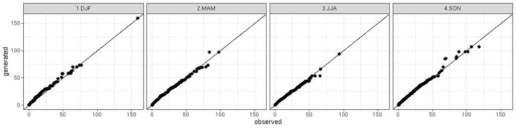

```r
library(ggplot2)
library(lubridate)
library(reshape2)
df <- data.frame(obs=prec_mes[,it1],gen=prec_gen1[,it1])
df$date <- as.Date(origin)+days(1:nrow(df))-1
df$month <- factor(month(df$date))
df$season <- "none"
df$season[df$month %in% c(12,2,1)] <- "`1.DJF"
df$season[df$month %in% c(3,4,5)] <-  "2.MAM"
df$season[df$month %in% c(6,7,8)] <-  "3.JJA"
df$season[df$month %in% c(9,10,11)] <-  "4.SON"
qqplot_ <- function(df) {
  df <- as.list(df)
  o <- qqplot(df[[1]],df[[2]],plot.it=FALSE)
  names(o) <- names(df)[1:2]
  o <- as.data.frame(o)
  return(o)

}

qqdf <- split(df,f=df$season) %>% lapply(FUN=qqplot_) %>% melt(id=names(df)[1:2])
names(qqdf)[names(qqdf)=="L1"] <- "season"
g <- ggplot(data=qqdf)+geom_point(aes(x=obs,y=gen))+theme_bw()+geom_abline()+facet_grid(. ~ season)+xlab("observed")+ylab("generated")
show(g)
```

A comparison of the dry/wet spells, considered as periods of consecutive dry/rainy days, between observed and generated time series are plotted below respectively. The following lines of codes makes use of *dw.spell* function that calculates the length expressed in days for the dry or wet spells:

```r
dw <- list()
dw$obs <- dw.spell(prec_mes[,it1],origin=origin)[[1]]
dw$obs$variable <- "obs"
dw$gen <- dw.spell(prec_gen1[,it1],origin=origin)[[1]]
dw$gen$variable <- "gen"
dw <- do.call(what=rbind,args=dw)
dw$season <- "none"
dw$season[dw$month %in% c(12,2,1)] <- "`1.DJF"
dw$season[dw$month %in% c(3,4,5)] <-  "2.MAM"
dw$season[dw$month %in% c(6,7,8)] <-  "3.JJA"
dw$season[dw$month %in% c(9,10,11)] <-  "4.SON"

qqdw <- split(dw,f=paste(dw$spell_state,dw$season,sep="_")) %>% lapply(FUN=function(x){list(obs=x$spell_length[x$variable=="obs"],gen=x$spell_length[x$variable=="gen"])}) %>% lapply(FUN=qqplot_) %>% melt(id=c("obs","gen"))
qqdw_add <- str_split(qqdw$L1,pattern="_") %>% do.call(what=rbind) %>% as.data.frame()
names(qqdw_add) <- c("state","season")
qqdw <- cbind(qqdw,qqdw_add)
```

Therefore, the quantile-quantile plots for the dry spells are:

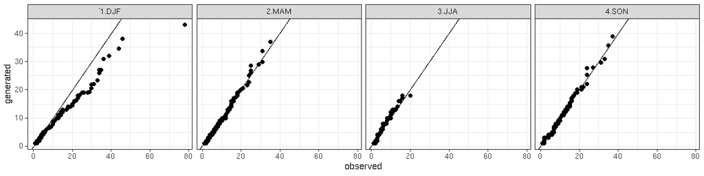

```r
qqdry <- qqdw[qqdw$state=="dry",]

## ggplot plot
ggdry <- ggplot(data=qqdry)+geom_point(aes(x=obs,y=gen))+theme_bw()+geom_abline()+facet_grid(. ~ season)+xlab("observed")+ylab("generated")
show(ggdry)
```

Analogously for the wet spells it is:

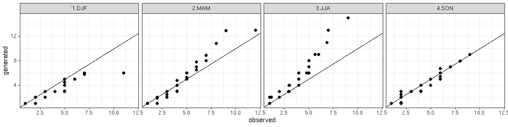

```r
qqwet <- qqdw[qqdw$state=="wet",]

## ggplot plot
ggwet <- ggplot(data=qqwet)+geom_point(aes(x=obs,y=gen))+theme_bw()+geom_abline()+facet_grid(. ~ season)+xlab("observed")+ylab("generated")
show(ggwet)
```

It is a comparison of sample probability distributtions of daily precipitation, dry and wet spells between the one obtained by the observed time series and the generated time series.

## Generation of Precipitation in Several Stations

### Occurrence

Analogously as the one-site case, a precipitation occurrence generator is created from precipitation time series taken in several correlated sites belonging to a limited geographical area. For instance, a subset of Trentino dataset stations is taken into account:

```r
they <- c("T0083","T0090") ##station
exogen <- Tx_mes[,they]-Tn_mes[,they]
months <- factor(prec_mes$month)
model <- PrecipitationOccurrenceMultiSiteModel(x=prec_mes[,they],exogen=exogen,origin=origin)
```

where *model* cotains the following elements:

```r
names(model)
```

```
#> [1] "T0083"   "T0090"   "ccgamma" "K"       "type"    "station" "p"
```

```r
class(model[[1]])
```

```
#> [1] "PrecipitationOccurrenceModel"
```

and the remaining ones are:

```r
class(model$ccgamma)
```

```
#> [1] "CCGammaObjectListPerEachMonth"
```

in which *ccgamma* is a matrix of corresponding Gaussian correlation of precipitation occurrences calculated with the algorithm introduced by Wilks (1998); this method makes use of a bijective relationships between correlation of binomial processes and Gaussian processes and is used alternatively to a complete logistic regression among stations that would have been computationally heavier;

```r
class(model$K)
```

```
#> [1] "integer"
```

in which *K* corresponds to the dimensionality (i.e. the number of the gauging stations);

```r
class(model$type)
```

```
#> [1] "character"
```

in which *type* is the type of the model: in this case, it is based on Wilks’ approach to handle the plurality of the gauging stations;

```r
class(model$station)
```

```
#> [1] "character"
```

in which *station* is a vector of the names of the gauging stations;

```r
class(model$p)
```

```
#> [1] "numeric"
```

in which *p* is the lag order of autoregression for the generalized linear model. Therefore, the stochastic generation is made by applying *generate* method to the model:

```r
prec_gen_occ <- generate(model,exogen=exogen,monthly.factor=months,n=length(months))
```

```
#> Processing T0083
#> Processing T0090
```

```r
str(prec_gen_occ)
```

```
#> 'data.frame':    10957 obs. of  2 variables:
#>  $ T0083: logi [1:10957(1d)] FALSE TRUE TRUE TRUE FALSE FALSE ...
#>  $ T0090: logi [1:10957(1d)] FALSE TRUE TRUE TRUE FALSE FALSE ...
```

### Amount

The precipitation amount stochastic generator is then built as follows:

```r
model_amount <- PrecipitationAmountModel(prec_mes,station=they,origin=origin)
names(model_amount)
```

```
#> [1] "T0083"   "T0090"   "station" "sample"  "x"       "origin"  "valmin"
```

where *model_amount* is an S3 object:

```r
class(model_amount)
```

```
#> [1] "PrecipitationAmountModel"
```

containing the following items:

```r
names(model_amount)
```

```
#> [1] "T0083"   "T0090"   "station" "sample"  "x"       "origin"  "valmin"
```

The first elements are generalized linear models, in which Gaussianized values of precipitation depend on month of the year:

```r
for (its in model_amount$station) summary(model_amount[[its]])
```

In the following, the model contains also a vector with the name of the gauging stations and other options like for the case with only one gauging station:

```r
model_amount$station
```

```
#> [1] "T0083" "T0090"
```

```r
model_amount$sample
```

```
#> [1] "monthly"
```

```r
model_amount$origin
```

```
#> [1] "1961-1-1"
```

```r
model_amount$valmin
```

```
#> [1] 1
```

Finally, a data frame with the generated times series for each gauging station site is obtained as follows:

```r
prec_gen <- generate(model_amount,newdata=prec_gen_occ)

names(prec_gen)
```

```
#> [1] "T0083" "T0090"
```

### Comparison

Quantile-quantile plots for precipitation time series both station are created as follows (if not specified, measurment units are millimiters):

```r
library(ggplot2)
library(lubridate)
library(reshape2)

str(prec_mes)
```

```
#> 'data.frame':    10957 obs. of  12 variables:
#>  $ month: int  1 1 1 1 1 1 1 1 1 1 ...
#>  $ day  : num [1:10957(1d)] 1 2 3 4 5 6 7 8 9 10 ...
#>  $ year : int  1961 1961 1961 1961 1961 1961 1961 1961 1961 1961 ...
#>  $ T0001: num  0 10.8 0 22.2 0 0 2.8 0 0 0 ...
#>  $ T0014: num  0 7.38 0 25.56 0 ...
#>  $ T0064: num  0 14 0 32.5 0 0 0 0 0 0 ...
#>  $ T0083: num  0 6.76 0 61.5 0 ...
#>  $ T0090: num  0 0 0 13 0 ...
#>  $ T0129: num  0 12.9 0.172 33.368 0 ...
#>  $ T0139: num  0 9.43 0 17.25 0 ...
#>  $ T0211: num  1.3 15.5 0 38.3 0 0 7.6 0 0 0 ...
#>  $ T0367: num  0 10.4 0 8 0 1 0 0 0 4.5 ...
```

```r
str(prec_gen)
```

```
#> 'data.frame':    10957 obs. of  2 variables:
#>  $ T0083: num  0 3.21 8.52 21.4 0 ...
#>  $ T0090: num  0 13.49 7.68 7.68 0 ...
```

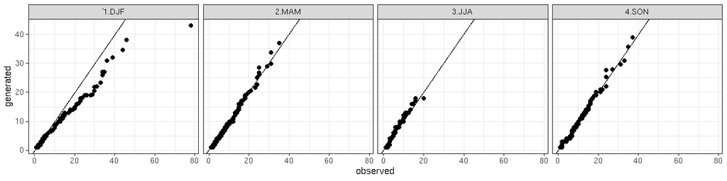

```r
df <- list(obs=prec_mes[names(prec_gen)],gen=prec_gen)
for ( i in 1:length(df)) {
  df[[i]]$date <- as.Date(origin)+days(1:nrow(df[[i]]))-1
}


df <- melt(df,id="date")
names(df)[names(df)=="variable"] <- "station"
names(df)[names(df)=="L1"] <- "variable"
df$month <- factor(month(df$date))
df$season <- "none"
df$season[df$month %in% c(12,2,1)] <- "1.DJF"
df$season[df$month %in% c(3,4,5)] <-  "2.MAM"
df$season[df$month %in% c(6,7,8)] <-  "3.JJA"
df$season[df$month %in% c(9,10,11)] <-  "4.SON"

qqdf <- split(df,f=paste(df$station,df$season,sep="_")) %>%
lapply(FUN=function(x){list(obs=x$value[x$variable=="obs"],gen=x$value[x$variable=="gen"])}) %>% lapply(FUN=qqplot_) %>% melt(id=c("obs","gen"))
qqdf_add <- str_split(qqdf$L1,pattern="_") %>% do.call(what=rbind) %>% as.data.frame()
names(qqdf_add) <- c("station","season")
qqdf <- cbind(qqdf,qqdf_add)

## ggplot plot
ggdf <- ggplot(data=qqdf)+geom_point(aes(x=obs,y=gen))+theme_bw()+geom_abline()+facet_grid(station ~ season)+xlab("observed")+ylab("generated")
show(ggdry)
```

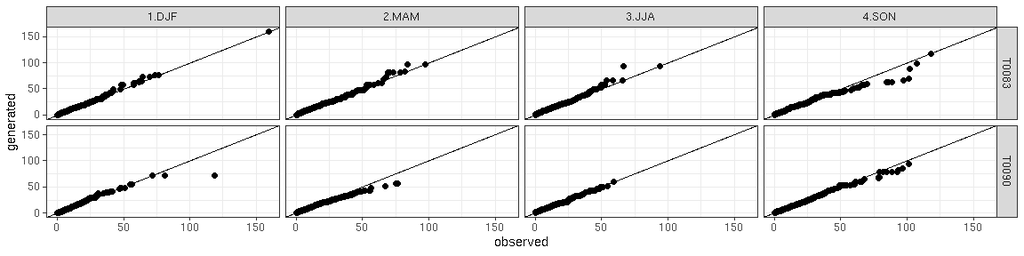

```r
show(ggdf)
```

As concerns the representation and analysis of dry/wet spells, the respective quantile-quantile plots has been produces as follows:

```r
dw <- list()
dw$obs <- dw.spell(prec_mes[,they],origin=origin)
nn <- names(dw$obs[[1]])
dw$obs <- melt(dw$obs,id=nn)
dw$obs$variable <- "obs"
dw$gen <- dw.spell(prec_gen[,they],origin=origin) %>% melt(id=nn)
dw$gen$variable <- "gen"

dw <- do.call(what=rbind,args=dw)
names(dw)[names(dw)=="L1"] <- "station"

dw$season <- "none"
dw$season[dw$month %in% c(12,2,1)] <- "`1.DJF"
dw$season[dw$month %in% c(3,4,5)] <-  "2.MAM"
dw$season[dw$month %in% c(6,7,8)] <-  "3.JJA"
dw$season[dw$month %in% c(9,10,11)] <-  "4.SON"

qqdw <- split(dw,f=paste(dw$spell_state,dw$station,dw$season,sep="_")) %>% lapply(FUN=function(x){list(obs=x$spell_length[x$variable=="obs"],gen=x$spell_length[x$variable=="gen"])}) %>% lapply(FUN=qqplot_) %>% melt(id=c("obs","gen"))

qqdw_add <- str_split(qqdw$L1,pattern="_") %>% do.call(what=rbind) %>% as.data.frame()
names(qqdw_add) <- c("state","station","season")
qqdw <- cbind(qqdw,qqdw_add)
```

Finally, the quantile-quantile plots for the dry spells are:

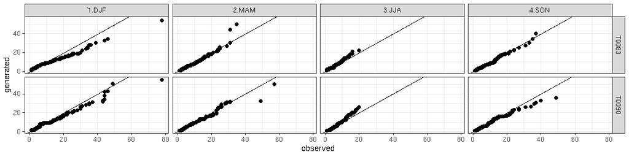

```r
qqdry <- qqdw[qqdw$state=="dry",]

## ggplot plot
ggdry <- ggplot(data=qqdry)+geom_point(aes(x=obs,y=gen))+theme_bw()+geom_abline()+facet_grid(station  ~ season)+xlab("observed")+ylab("generated")
show(ggdry)
```

and the quantile-quantile plots for the wet spells are:

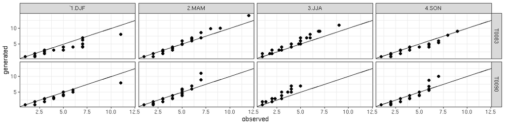

```r
qqwet <- qqdw[qqdw$state=="wet",]

## ggplot plot
ggwet <- ggplot(data=qqwet)+geom_point(aes(x=obs,y=gen))+theme_bw()+geom_abline()+facet_grid(station  ~ season)+xlab("observed")+ylab("generated")
show(ggwet)
```

The comparison of sample probability distribution between observed and generated timeseries has been tested for each month of the year:

```r
      months <- unique(prec_mes$month)
      ks_test <- list()
      for (m in months) {

        ks_test[[m]] <- ks.test(prec_mes[prec_mes$month==m,it1],prec_gen[prec_mes$month==m,it1])
      }
      ks_test
```

```
#> [[1]]
#>
#>  Two-sample Kolmogorov-Smirnov test
#>
#> data:  prec_mes[prec_mes$month == m, it1] and prec_gen[prec_mes$month == m, it1]
#> D = 0.034409, p-value = 0.6407
#> alternative hypothesis: two-sided
#>
#>
#> [[2]]
#>
#>  Two-sample Kolmogorov-Smirnov test
#>
#> data:  prec_mes[prec_mes$month == m, it1] and prec_gen[prec_mes$month == m, it1]
#> D = 0.029516, p-value = 0.8543
#> alternative hypothesis: two-sided
#>
#>
#> [[3]]
#>
#>  Two-sample Kolmogorov-Smirnov test
#>
#> data:  prec_mes[prec_mes$month == m, it1] and prec_gen[prec_mes$month == m, it1]
#> D = 0.04086, p-value = 0.4193
#> alternative hypothesis: two-sided
#>
#>
#> [[4]]
#>
#>  Two-sample Kolmogorov-Smirnov test
#>
#> data:  prec_mes[prec_mes$month == m, it1] and prec_gen[prec_mes$month == m, it1]
#> D = 0.037778, p-value = 0.5419
#> alternative hypothesis: two-sided
#>
#>
#> [[5]]
#>
#>  Two-sample Kolmogorov-Smirnov test
#>
```

[output cut: 51 more lines]

```
#>
#>  Two-sample Kolmogorov-Smirnov test
#>
#> data:  prec_mes[prec_mes$month == m, it1] and prec_gen[prec_mes$month == m, it1]
#> D = 0.042222, p-value = 0.3987
#> alternative hypothesis: two-sided
#>
#>
#> [[12]]
#>
#>  Two-sample Kolmogorov-Smirnov test
#>
#> data:  prec_mes[prec_mes$month == m, it1] and prec_gen[prec_mes$month == m, it1]
#> D = 0.03871, p-value = 0.4888
#> alternative hypothesis: two-sided
```

In conclusion, the spatial statistical correlation between observed and generated time series can be checked making use of *CCGamma* function:

```r
str(prec_mes[,they])
```

```
#> 'data.frame':    10957 obs. of  2 variables:
#>  $ T0083: num  0 6.76 0 61.5 0 ...
#>  $ T0090: num  0 0 0 13 0 ...
```

```r
str(prec_gen[,they])
```

```
#> 'data.frame':    10957 obs. of  2 variables:
#>  $ T0083: num  0 3.21 8.52 21.4 0 ...
#>  $ T0090: num  0 13.49 7.68 7.68 0 ...
```

```r
cc_mes <- CCGamma(prec_mes[,they],sample = "monthly",origin = origin)
cc_gen <- CCGamma(prec_gen[,they],sample = "monthly",origin = origin)
```

where *cc_mes* and *cc_gen* are lists containing joint probability and correlation matrices among precipitation occurrences for each couple of sites. In case of *sample=monthly* setting, these matrices are replicated for each of the 12 months of the year. The structures of *cc_mes* and *cc_gen* can be displayed as follows:

```r
str(cc_mes)
str(cc_gen)
```

Then, the estimated correlation matrix of no-precipitation occurrence per each month of the year and for observed time series is:

```
#> $`1`
#>           [,1]      [,2]
#> [1,] 1.0000000 0.7172415
#> [2,] 0.7172415 1.0000000
#>
#> $`2`
#>           [,1]      [,2]
#> [1,] 1.0000000 0.7185805
#> [2,] 0.7185805 1.0000000
#>
#> $`3`
#>           [,1]      [,2]
#> [1,] 1.0000000 0.7603387
#> [2,] 0.7603387 1.0000000
#>
#> $`4`
#>           [,1]      [,2]
#> [1,] 1.0000000 0.7686571
#> [2,] 0.7686571 1.0000000
#>
#> $`5`
#>           [,1]      [,2]
#> [1,] 1.0000000 0.6891203
#> [2,] 0.6891203 1.0000000
#>
#> $`6`
#>           [,1]      [,2]
#> [1,] 1.0000000 0.6421596
#> [2,] 0.6421596 1.0000000
#>
#> $`7`
#>           [,1]      [,2]
#> [1,] 1.0000000 0.6617584
#> [2,] 0.6617584 1.0000000
#>
#> $`8`
#>           [,1]      [,2]
#> [1,] 1.0000000 0.6778738
#> [2,] 0.6778738 1.0000000
#>
#> $`9`
#>           [,1]      [,2]
#> [1,] 1.0000000 0.7237239
#> [2,] 0.7237239 1.0000000
#>
#> $`10`
#>           [,1]      [,2]
#> [1,] 1.0000000 0.8075086
#> [2,] 0.8075086 1.0000000
#>
#> $`11`
#>          [,1]     [,2]
#> [1,] 1.000000 0.784554
#> [2,] 0.784554 1.000000
#>
#> $`12`
#>           [,1]      [,2]
#> [1,] 1.0000000 0.7486674
#> [2,] 0.7486674 1.0000000
```

```
#> $`1`
#>           [,1]      [,2]
#> [1,] 1.0000000 0.5684831
#> [2,] 0.5684831 1.0000000
#>
#> $`2`
#>           [,1]      [,2]
#> [1,] 1.0000000 0.6876702
#> [2,] 0.6876702 1.0000000
#>
#> $`3`
#>           [,1]      [,2]
#> [1,] 1.0000000 0.6979002
#> [2,] 0.6979002 1.0000000
#>
#> $`4`
#>           [,1]      [,2]
#> [1,] 1.0000000 0.6766009
#> [2,] 0.6766009 1.0000000
#>
#> $`5`
#>           [,1]      [,2]
#> [1,] 1.0000000 0.5829847
#> [2,] 0.5829847 1.0000000
#>
#> $`6`
#>           [,1]      [,2]
#> [1,] 1.0000000 0.5454573
#> [2,] 0.5454573 1.0000000
#>
#> $`7`
#>           [,1]      [,2]
#> [1,] 1.0000000 0.5905328
#> [2,] 0.5905328 1.0000000
#>
#> $`8`
#>          [,1]     [,2]
#> [1,] 1.000000 0.576023
#> [2,] 0.576023 1.000000
#>
#> $`9`
#>           [,1]      [,2]
#> [1,] 1.0000000 0.6046216
#> [2,] 0.6046216 1.0000000
#>
#> $`10`
#>           [,1]      [,2]
#> [1,] 1.0000000 0.7097068
#> [2,] 0.7097068 1.0000000
#>
#> $`11`
#>           [,1]      [,2]
#> [1,] 1.0000000 0.6752921
#> [2,] 0.6752921 1.0000000
#>
#> $`12`
#>           [,1]      [,2]
#> [1,] 1.0000000 0.6298554
#> [2,] 0.6298554 1.0000000
```

## Modifying Precipitation Distribution (e.g. Precipitation Futture Projection)

Let assume that once tested and verified the stochastic generation model, the precipitation stochastic generator may be used to generate a time series with specific probability distribution of daily precipitation (e.g. future climate change scenarios). The observed daily precipitation sample distribution for the reference station is retrieved and plotted as follows:

```r
df <- data.frame(obs=prec_mes[,it1],gen=prec_gen1[,it1])
df$date <- as.Date(origin)+days(1:nrow(df))-1
df$month <- factor(month(df$date))
df$season <- "none"
df$season[df$month %in% c(12,2,1)] <- "1.DJF"
df$season[df$month %in% c(3,4,5)] <-  "2.MAM"
df$season[df$month %in% c(6,7,8)] <-  "3.JJA"
df$season[df$month %in% c(9,10,11)] <-  "4.SON"

dfp <- df[df$obs>valmin,]
```

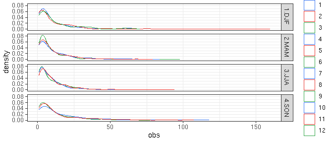

```r
color_month <-  rep(c("#E6352F","#34A74B","#3D79F3" ),4)[c(12,1:11)]

gdens <- ggplot(data=dfp)+geom_density(aes(x=obs,color=month,group=month),trim=TRUE)+facet_grid(season ~ .)+theme_bw()
gdens <- gdens+scale_color_manual(values = color_month)

show(gdens)
```

Though the method of L-moments (Hosking (2019)) , the monthly samples of daily precipitation are fitted with a LN3 (Sangal and Biswas (1970)) distribution, in most of months the null hypothesis of the Kolgormov-Smirnov test can be accepted (*pvalue>0.1*):

```r
library(lmom)

prec_val_m <- dfp$obs %>% split(dfp$month)
lmoms <- prec_val_m %>% lapply(FUN=samlmu)

params <- lmoms %>% lapply(FUN=pelln3,bound=valmin)
kstest <-params %>% mapply(FUN=ks.test,x=prec_val_m,y="cdfln3",SIMPLIFY=FALSE)











kstest
```

```
#> $`1`
#>
#>  One-sample Kolmogorov-Smirnov test
#>
#> data:  dots[[2L]][[1L]]
#> D = 0.085787, p-value = 0.2132
#> alternative hypothesis: two-sided
#>
#>
#> $`2`
#>
#>  One-sample Kolmogorov-Smirnov test
#>
#> data:  dots[[2L]][[2L]]
#> D = 0.10099, p-value = 0.09575
#> alternative hypothesis: two-sided
#>
#>
#> $`3`
#>
#>  One-sample Kolmogorov-Smirnov test
#>
#> data:  dots[[2L]][[3L]]
#> D = 0.061355, p-value = 0.4262
#> alternative hypothesis: two-sided
#>
#>
#> $`4`
#>
#>  One-sample Kolmogorov-Smirnov test
#>
#> data:  dots[[2L]][[4L]]
#> D = 0.10053, p-value = 0.01801
#> alternative hypothesis: two-sided
#>
#>
#> $`5`
#>
#>  One-sample Kolmogorov-Smirnov test
#>
```

[output cut: 51 more lines]

```
#>
#>  One-sample Kolmogorov-Smirnov test
#>
#> data:  dots[[2L]][[11L]]
#> D = 0.083505, p-value = 0.1054
#> alternative hypothesis: two-sided
#>
#>
#> $`12`
#>
#>  One-sample Kolmogorov-Smirnov test
#>
#> data:  dots[[2L]][[12L]]
#> D = 0.09957, p-value = 0.1459
#> alternative hypothesis: two-sided
```

Making the assumption that daily precipitation amount behaves as a random variable distributed with a LN3 probability distribution, a new scernario is created with a more flatten distrution than the estimated one from observations by increasing the value of 2th L-moment. Through the computation of quantiles a relationship between observed and artificial scenerios has been assessed for each month of the year and then plotted:

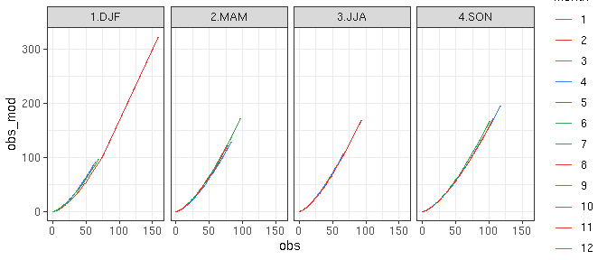

```r
modify_lmoments <- function(x){x[2] <- x[2]*1.3; return(x)}
paraml <- function(x,valmin) {
                  ip <- which(x>=valmin)
                  x <- x[ip]
                  out <- list()
                  lmomx <- samlmu(x)
                  out$obs <- pelln3(lmom=lmomx,bound=valmin)
                  lmomx_m <- modify_lmoments(lmomx)
                  out$mod  <- pelln3(lmom=lmomx_m,bound=valmin)
                  return(out)
}

modify_distribution <- function(x,paraml,valmin){

                        out <- x
                        ip <- which(x>=valmin)
                        out[ip] <- x[ip] %>% cdfln3(para=paraml$obs) %>% qualn3(para=paraml$mod)
                        return(out)

}


para_monthly <- df$obs %>% split(df$month) %>% lapply(FUN=paraml,valmin=valmin)

df$obs_mod <- df$obs
for (mo in unique(df$month))  {
  im <- which(df$month==mo)

  df$obs_mod[im] <- modify_distribution(x=df$obs[im],paraml=para_monthly[[mo]],valmin=valmin)
}
color_month <-  rep(c("#E6352F","#34A74B","#3D79F3" ),4)[c(12,1:11)]
gg <- ggplot()+geom_line(data=df,mapping=aes(x=obs,y=obs_mod,col=month))+facet_grid(. ~ season)+theme_bw()
gg <- gg+scale_color_manual(values = color_month)
show(gg)
```

The above figure shows the relation of each month of the year between real observations (*obs*) and modified observations (*obs_mod*). The shape looks like a parabolic one with an quasi-exponential increasing for high values (above 100 mm). This means that a daily precipitation value above 100 mm may become (if variabilty increases) 1.5 or 2 times higher. Analogously, considering the scenorio gived by *obs_mod* time series, a precipitation amount model has been built and then used for a new stochastic generation:

```r
prec_mod <- as.data.frame(df$obs_mod)
names(prec_mod) <- it1
model1_amount_mod <- PrecipitationAmountModel(prec_mod,station=it1,origin=origin)
prec_gen1_mod <- generate(model1_amount_mod,newdata=prec_gen1_occ)
str(prec_gen1_mod)
```

```
#> 'data.frame':    10957 obs. of  1 variable:
#>  $ T0083: num  0 3.96 2.19 1.05 0 ...
```

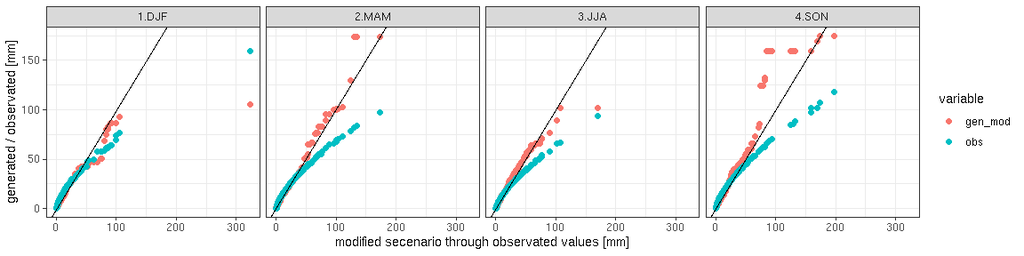

```r
df$gen_mod <- prec_gen1_mod[,it1]

qqplot__ <- function(df,i=1) {
  df <- as.list(df)
  o <- list()
  nn <- names(df)
  jv <- (1:length(df))[-i]
  for (j in jv) {
    ot <- qqplot(df[[i]],df[[j]],plot.it=FALSE)
    ot <- as.data.frame(ot)
    names(ot) <- names(df)[c(i,j)]
    o[[j]] <- ot
  }
  ref <- o[[jv[1]]][,1]
  for (j in jv[-1]) {
    ref2 <-  o[[j]][,1]
    cond <- all(ref==ref2)
    if (cond==FALSE) stop("qqplot__ error")


  }
  o <- do.call(args=o[jv],what=cbind)
  o <- o[,nn] %>% melt(id=1)


  return(o)
}

nnn <- c("obs_mod","gen_mod","obs")

qqdf <- split(df[,nnn],f=df$season) %>% lapply(FUN=qqplot__) %>% melt(id=1:3)
names(qqdf)[names(qqdf)=="L1"] <- "season"
g <- ggplot(data=qqdf)+geom_point(aes(x=obs_mod,y=value,group=variable,color=variable))+theme_bw()+geom_abline()+facet_grid(. ~ season)+xlab("modified secenario through observated values [mm]")+ylab("generated / observated [mm]")
show(g)
```

## Conclusions

An example of the usage of the precipitation stochastic generation contained in **RGENERATEPREC** package has been shown. Visualization through quantile-quantile plots and statistical testing (e.g. Kolgomorov-Smirnov testing), the similarity of the stastistical properties (e.g. probability distrubtions of precipitation occurrence, precipitation account, dry spell, wet spell per each month of the year) between observed and generated time series hes been checked. The weather generator can work with one or more time series generating scenarios for several sites and mantaining their also spatial cross-correlation. This vignette has shown an example applied to some stations of *trentino* dataset. An example on how to use the weather generator with data having different probabilistic distribution (e.g. more climate variability or adaptations to future projections) has been finally illustrated.

## References

Adenomon, MO, and BA Oyejola. 2013. “Impact of Agriculture and Industrialization on GDP in Nigeria: Evidence from VAR and SVAR Models.” *International Journal of Analysis and Applications* 1 (1): 40–78.

Ahn, Kuk-Hyun, and Scott Steinschneider. 2018. “Time-Varying Suspended Sediment-Discharge Rating Curves to Estimate Climate Impacts on Fluvial Sediment Transport.” *Hydrological Processes* 32 (1): 102–17. https://doi.org/10.1002/hyp.11402.

Alikadic, Azra, Ilaria Pertot, Emanuele Eccel, Claudia Dolci, Calogero Zarbo, Amelia Caffarra, Riccardo De Filippi, and Cesare Furlanello. 2019. “The Impact of Climate Change on Grapevine Phenology and the Influence of Altitude: A Regional Study.” *Agricultural and Forest Meteorology* 271: 73–82. https://doi.org/https://doi.org/10.1016/j.agrformet.2019.02.030.

Bárdossy, A., and G. Pegram. 2009. “Copula Based Multisite Model for Daily Precipitation Simulation.” *Hydrol. Earth Syst. Sci. Discuss.* 6 (3): 4485–4534. https://doi.org/10.5194/hessd-6-4485-2009.

Benmoussa, Haïfa, Mehdi Ben Mimoun, Mohamed Ghrab, and Eike Luedeling. 2018. “Climate Change Threatens Central Tunisian Nut Orchards.” *International Journal of Biometeorology* 62 (12): 2245–55. https://doi.org/10.1007/s00484-018-1628-x.

Bivand, Roger S., Edzer J. Pebesma, and Virgilio Gomez-Rubio. 2008. *Applied Spatial Data Analysis with R*. Springer, NY.

Brissette, F. P., M. Khalili, and R. Leconte. 2007. “Efficient Stochastic Generation of Multi-Site Synthetic Precipitation Data.” *Journal of Hydrology* 345 (3–4): 121–33. https://www.sciencedirect.com/science/article/pii/S002216940700385X.

Chen, J., F. P. Brissette, and R. Leconte. 2012. “WeaGETS – a Matlab-Based Daily Scale Weather Generator for Generating Precipitation and Temperature.” *Procedia Environmental Sciences* 13 (0): 2222–35. https://doi.org/http://dx.doi.org/10.1016/j.proenv.2012.01.211.

Chen, Jie, and François P. Brissette. 2014. “Comparison of Five Stochastic Weather Generators in Simulating Daily Precipitation and Temperature for the Loess Plateau of China.” *International Journal of Climatology*, n/a–. https://doi.org/10.1002/joc.3896.

Cheng, Joe, Bhaskar Karambelkar, and Yihui Xie. 2018. *Leaflet: Create Interactive Web Maps with the JavaScript ’Leaflet’ Library*. https://CRAN.R-project.org/package=leaflet.

Cordano, Emanuele. 2015. *RGENERATE: Tools to Generate Vector Time Series*. https://CRAN.R-project.org/package=RGENERATE.

Cordano, Emanuele, and Emanuele Eccel. 2016. “Tools for Stochastic Weather Series Generation in r Environment.” *Italian Journal of Agrometeorology* 3. https://doi.org/10.19199/2016.3.2038-5625.031.

———. 2019. *RMAWGEN: Multi-Site Auto-Regressive Weather GENerator*. https://CRAN.R-project.org/package=RMAWGEN.

Delerce, Sylvain, Hugo Dorado, Alexandre Grillon, Maria Camila Rebolledo, Steven D. Prager, Victor Hugo Patiño, Gabriel Garcés Varón, and Daniel Jiménez. 2016. “Assessing Weather-Yield Relationships in Rice at Local Scale Using Data Mining Approaches.” *PloS One* 11 (8): e0161620–20. https://doi.org/10.1371/journal.pone.0161620.

Fu, Guobin, Francis H. S. Chiew, and Xiaogang Shi. 2018. “Generation of Multi-Site Stochastic Daily Rainfall with Four Weather Generators: A Case Study of Gloucester Catchment in Australia.” *Theoretical and Applied Climatology* 134 (3): 1027–46. https://doi.org/10.1007/s00704-017-2306-3.

Hosking, J. R. M. 2019. *L-Moments*. https://CRAN.R-project.org/package=lmom.

Kahle, David, and Hadley Wickham. 2013. *Ggmap: A Package for Spatial Visualization with Google Maps and OpenStreetMap*. https://cran.R-project.org/package=ggmap.

Khalili, Malika, François Brissette, and Robert Leconte. 2009. “Stochastic Multi-Site Generation of Daily Weather Data.” *Stochastic Environmental Research and Risk Assessment* 23: 837–49. http://dx.doi.org/10.1007/s00477-008-0275-x.

Liu, Junguo, Jimmy R. Williams, Xiuying Wang, and Hong Yang. 2009. “Using MODAWEC to Generate Daily Weather Data for the EPIC Model.” *Environmental Modelling & Software* 24 (5): 655–64. https://doi.org/http://dx.doi.org/10.1016/j.envsoft.2008.10.008.

Loecher, Markus, and Berlin School of Economics and Law. 2012. *RgoogleMaps: Overlays on Google Map Tiles in r*. https://cran.R-project.org/package=RgoogleMaps.

Luguterah, Albert, Suleman Nasiru, and Lea Anzagra. 2013. “Dynamic Relationship Between Production Growth Rates of Three Major Cereals in Ghana.” *Mathematical Theory and Modeling* 3 (8): 68–75.

Mearns, L. O., W. Easterling, C. Hays, and D. Marx. 2001. “Comparison of Agricultural Impacts of Climate Change Calculated from High and Low Resolution Climate Change Scenarios: Part i. The Uncertainty Due to Spatial Scale.” *Climatic Change* 51: 131–72. http://dx.doi.org/10.1023/A:1012297314857.

Mehrotra, R., R. Srikanthan, and Ashish Sharma. 2006. “A Comparison of Three Stochastic Multi-Site Precipitation Occurrence Generators.” *Journal of Hydrology* 331 (1-2): 280–92. https://doi.org/10.1016/j.jhydrol.2006.05.016.

Mhanna, Muamaraldin, and Willy Bauwens. 2011. “A Stochastic Space-Time Model for the Generation of Daily Rainfall in the Gaza Strip.” *International Journal of Climatology*, n/a–. https://doi.org/10.1002/joc.2305.

Parlange, Marc B., and Richard W. Katz. 01 May. 2000. “An Extended Version of the Richardson Model for Simulating Daily Weather Variables.” *Journal of Applied Meteorology* 39 (5): 610–22.

Pfaff, Bernhard. 2008. “VAR, SVAR and SVEC Models: Implementation Within R Package vars.” *Journal of Statistical Software* 27 (4). https://www.jstatsoft.org/v27/i04/.

Qian, Budong, João Corte-Real, and Hong Xu. 2002. “Multisite Stochastic Weather Models for Impact Studies.” *International Journal of Climatology* 22 (11): 1377–97. https://doi.org/http://dx.doi.org/10.1002/joc.808.

Racsko, P., L. Szeidl, and M. Semenov. 1991. “A Serial Approach to Local Stochastic Weather Models.” *Ecological Modelling* 57 (1-2): 27–41. https://doi.org/10.1016/0304-3800(91)90053-4.

Richardson, C. W. 1981. “Stochastic Simulation of Daily Precipitation, Temperature, and Solar Radiation.” *Water Resources Research* 17 (1): 182–90. https://agupubs.onlinelibrary.wiley.com/doi/abs/10.1029/WR017i001p00182.

Sangal, B. P., and Asit K. Biswas. 1970. “The 3-Parameter Lognormal Distribution and Its Applications in Hydrology.” *Water Resources Research* 6 (2): 505–15. https://agupubs.onlinelibrary.wiley.com/doi/abs/10.1029/WR006i002p00505.

Semenov, M. A., and P. Stratonovitch. 2010. “Use of Multi-Model Ensembles from Global Climate Models for Assessment of Climate Change Impacts.” *Climate Research* 41 (1): 1–14. http://www.int-res.com/abstracts/cr/v41/n1/p1-14/.

Semenov, Mikhail A., and Elaine M. Barrow. 1997. “Use of a Stochastic Weather Generator in the Development of Climate Change Scenarios.” *Climatic Change* 35 (4): 397–414. https://doi.org/10.1023/A:1005342632279.

Serinaldi, Francesco. 2009. “A Multisite Daily Rainfall Generator Driven by Bivariate Copula-Based Mixed Distributions.” *Journal of Geophysical Research: Atmospheres* 114 (D10). https://agupubs.onlinelibrary.wiley.com/doi/abs/10.1029/2008JD011258.

Shahin, Md. Abu, Md. Ayub Ali, and A. B. M. Shawkat Ali. 2014. “Vector Autoregression (VAR) Modeling and Forecasting of Temperature, Humidity, and Cloud Coverage.” In *Computational Intelligence Techniques in Earth and Environmental Sciences*, edited by Tanvir Islam, Prashant K. Srivastava, Manika Gupta, Xuan Zhu, and Saumitra Mukherjee, 29–51. Dordrecht: Springer Netherlands. https://doi.org/10.1007/978-94-017-8642-3_2.

Thompson, Craig S., Peter J. Thomson, and Xiaogu Zheng. 2007. “Fitting a Multisite Daily Rainfall Model to New Zealand Data.” *Journal of Hydrology* 340 (1-2): 25–39. https://doi.org/10.1016/j.jhydrol.2007.03.020.

Verdin, Andrew, Balaji Rajagopalan, William Kleiber, Guillermo Podestá, and Federico Bert. 2018. “A Conditional Stochastic Weather Generator for Seasonal to Multi-Decadal Simulations.” *Journal of Hydrology* 556: 835–46. https://doi.org/https://doi.org/10.1016/j.jhydrol.2015.12.036.

Wilks, D. S. 1998. “Multisite Generalization of a Daily Stochastic Precipitation Generation Model.” *Journal of Hydrology* 210 (1-4): 178–91. https://doi.org/10.1016/S0022-1694(98)00186-3.

Wilks, D. S., and R. L. Wilby. 1999. “The Weather Generation Game: A Review of Stochastic Weather Models.” *Progress in Physical Geography* 23 (3): 329–57. https://doi.org/10.1177/030913339902300302.